The goal of this vignette is to show how to use custom asymptotic references. As an example, we explore the differences in asymptotic time complexity between different implementations of binary segmentation.

## Asymptotic time/memory measurement of different R expressions

The code below uses the following arguments:

- `N` is a numeric vector of data sizes,
- `setup` is an R expression to create the data,
- the other arguments have names to identify them in the results, and values which are R expressions to time,

```r
library(data.table)
expr.list <- list()
if(requireNamespace("changepoint"))expr.list[["changepoint\n::cpt.mean"]] <- quote({
  cpt.fit <- changepoint::cpt.mean(data.vec, method="BinSeg", Q=max.changes)
  sort(c(N,cpt.fit@cpts.full[max.changes,]))
})
if(requireNamespace("binsegRcpp")){
  expr.list[["binsegRcpp\nmultiset"]] <- quote({
    binseg.fit <- binsegRcpp::binseg(
      "mean_norm", data.vec, max.segs, container.str="multiset")
    sort(binseg.fit$splits$end)
  })
  expr.list[["binsegRcpp\nlist"]] <- quote({
    binseg.fit <- binsegRcpp::binseg(
      "mean_norm", data.vec, max.segs, container.str="list")
    sort(binseg.fit$splits$end)
  })
}
if(requireNamespace("wbs"))expr.list[["wbs::sbs"]] <- quote({
  wbs.fit <- wbs::sbs(data.vec)
  split.dt <- data.table(wbs.fit$res)[order(-min.th, scale)]
  sort(split.dt[, c(N, cpt)][1:max.segs])
})
```

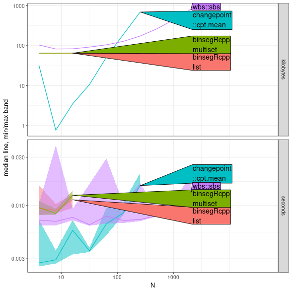

```r
seg.result <- atime::atime(
  N=2^seq(2, 20),
  setup={
    max.segs <- as.integer(N/2)
    max.changes <- max.segs-1L
    set.seed(1)
    data.vec <- 1:N
  },
  expr.list=expr.list)
plot(seg.result)
```

The plot method creates a log-log plot of median time and memory vs data size, for each of the specified R expressions. The plot above shows some speed differences between binary segmentation algorithms, but they could be even easier to see for larger data sizes (exercise for the reader: try modifying the `N` and `seconds.limit` arguments). You can also see that memory usage is much larger for changepoint than for the other packages.

You can use `references_best` to get a tall/long data table that can be plotted to show both empirical time and memory complexity:

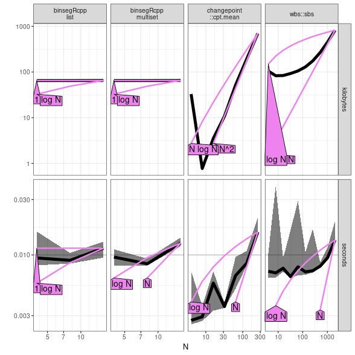

```r
seg.best <- atime::references_best(seg.result)
plot(seg.best)
```

The figure above shows asymptotic references which are best fit for each expression. We do the best fit by adjusting each reference to the largest N, and then ranking each reference by distance to the measurement of the second to largest N. For each panel/facet (method and unit), what appears to be the best fit asymptotic complexity? Which methods use quadratic time and/or memory?

## predict method

The predict method estimates the data size `N` which each method can handle for a given unit value. The default is to estimate `N` for a time limit of 0.01 seconds, as shown in the plot below:

```r
(seg.pred <- predict(seg.best))
```

```
#> atime_prediction object
#>       unit               expr.name unit.value          N
#>     <char>                  <char>      <num>      <num>
#> 1: seconds changepoint\n::cpt.mean       0.01  153.91286
#> 2: seconds    binsegRcpp\nmultiset       0.01   10.74615
#> 3: seconds        binsegRcpp\nlist       0.01   10.86753
#> 4: seconds                wbs::sbs       0.01 1142.57157
#>                             label
#>                            <char>
#> 1: changepoint\n::cpt.mean\nN=154
#> 2:     binsegRcpp\nmultiset\nN=11
#> 3:         binsegRcpp\nlist\nN=11
#> 4:              wbs::sbs\nN=1,143
```

```
#> log-10 transformation introduced infinite values.
```

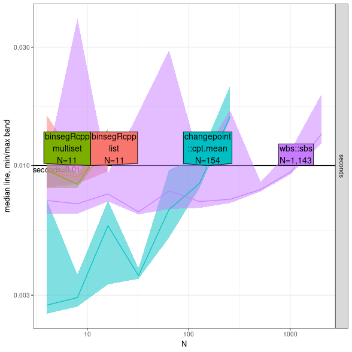

```r
plot(seg.pred)
```

## Custom asymptotic references

If you have one or more expected time complexity classes that you want to compare with your empirical measurements, you can use the `fun.list` argument. Note that each function in that list should take as input the data size `N` and output log base 10 of the reference function, as below:

```r
my.refs <- list(# names should be LaTeX math mode expressions.
  "N"=function(N)log10(N),
  "N \\log N"=function(N)log10(N) + log10(log(N)),
  "N^2"=function(N)2*log10(N),
  "N^3"=function(N)3*log10(N))
my.best <- atime::references_best(seg.result, fun.list=my.refs)
dcast(my.best$references, expr.name + fun.name ~ unit, length)
```

| expr.name | fun.name | kilobytes | seconds |
| --- | --- | --- | --- |
| binsegRcpp list | N | 3 | 2 |
| binsegRcpp list | N log N | 3 | 2 |
| binsegRcpp list | N^2 | 3 | 2 |
| binsegRcpp list | N^3 | 2 | 2 |
| binsegRcpp multiset | N | 3 | 2 |
| ⋮ | ⋮ | ⋮ | ⋮ |
| changepoint ::cpt.mean | N^3 | 3 | 2 |
| wbs::sbs | N | 10 | 3 |
| wbs::sbs | N log N | 8 | 2 |
| wbs::sbs | N^2 | 5 | 2 |
| wbs::sbs | N^3 | 4 | 2 |

The table above shows the counts of rows in the references table, which can be used to draw asymptotic reference curves, for each `expr.name`, `fun.name`, and unit (kilobytes and seconds). To compute the best fit among these references, we use the code below:

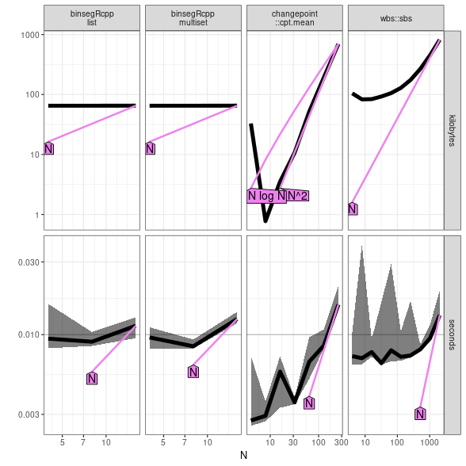

```r
plot(my.best)
```

The default plot above shows only the closest references which are above and below the empirical/black measurements. To plot different references and measurements, you can specify the `plot.references` and `measurements` elements. For example, in the code below, we subset the data so that only the seconds unit is shown (not kilobytes), and only three expected references are shown (log-linear, quadratic, cubic):

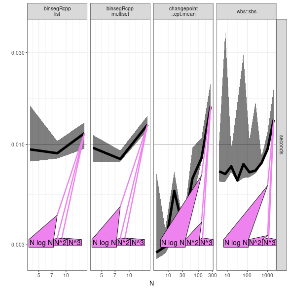

```r
some.best <- my.best
some.best$plot.references <- my.best$ref[unit=="seconds" & fun.name %in% c("N log N","N^2","N^3")]
some.best$measurements <- my.best$meas[unit=="seconds"]
plot(some.best)
```

From the plot above, you should be able to see the asymptotic time complexity class of each algorithm.

## Exercises for the reader

- increase `seconds.limit` to see the differences more clearly.
- compute and plot asymptotic references for memory instead of time (including expected memory complexity, linear).